# **Johns Hopkins University-Practical Machine Learning**

### *LIN, WEI-YU, Dec.22.2018*

## Background

Using devices such as Jawbone Up, Nike FuelBand, and Fitbit it is now possible to collect a large amount of data about personal activity relatively inexpensively.These type of devices are part of the quantified self movement – a group of enthusiasts who take measurements about themselves regularly to improve their health, to find patterns in their behavior. One thing that people regularly do is quantify how much of a particular activity they do, but they rarely quantify how well they do it. In this project, 6 participants were asked to perform barbell lifts correctly and incorrectly in 5 different ways, data from accelerometers on the belt, forearm, arm, and dumbell of these participants is used to analyze, thus to predict the manner in which they did the exercise.

## i.Exploring Data

```r
train <- read.csv("../pml-training.csv", header=TRUE)
test <- read.csv("../pml-testing.csv", header= TRUE)
```

```r
dim(train)
```

```
## [1] 19622   160
```

```r
dim(test)
```

```
## [1]  20 160
```

There are 160 variables in the dataset, with 19622 samples in the training set and 20 samples in the testing dataset.

```r
apply(train,2,is.null)
```

[output not shown]

[output cut: 53 more lines]

[output not shown]

```r
natrain <- apply(train,2,is.na)
natest <- apply(test,2,is.na)
nacnt_train <- apply(natrain, 2, sum)
nacnt_test <- apply(natest,2,sum)
indTrain <- lapply(nacnt_train, function(y){y!=19216})
indtest <- lapply(nacnt_test, function(y){y!=20})
ind <- ifelse(indTrain==1 & indtest==1,1,0)
max(nacnt_train)
```

```
## [1] 19216
```

```r
max(nacnt_test)
```

```
## [1] 20
```

It can be observed that there are at most 19216 NAs in each observations per variable. Since there are 19216 observations out of 19622 are NAs in few selected variables, instead of implementing imputations, removing these variables might be more optimal.

```r
library(caret)
train <- train[ind==1]
test <- test[ind==1]
names(test) <- names(train)
test <- test[,-60]
na <- apply(train,2, is.na)
apply(na,2,sum)
```

```
##                    X            user_name raw_timestamp_part_1
##                    0                    0                    0
## raw_timestamp_part_2       cvtd_timestamp           new_window
##                    0                    0                    0
##           num_window            roll_belt           pitch_belt
##                    0                    0                    0
##             yaw_belt     total_accel_belt         gyros_belt_x
##                    0                    0                    0
##         gyros_belt_y         gyros_belt_z         accel_belt_x
##                    0                    0                    0
##         accel_belt_y         accel_belt_z        magnet_belt_x
##                    0                    0                    0
##        magnet_belt_y        magnet_belt_z             roll_arm
##                    0                    0                    0
##            pitch_arm              yaw_arm      total_accel_arm
##                    0                    0                    0
##          gyros_arm_x          gyros_arm_y          gyros_arm_z
##                    0                    0                    0
##          accel_arm_x          accel_arm_y          accel_arm_z
##                    0                    0                    0
##         magnet_arm_x         magnet_arm_y         magnet_arm_z
##                    0                    0                    0
##        roll_dumbbell       pitch_dumbbell         yaw_dumbbell
##                    0                    0                    0
## total_accel_dumbbell     gyros_dumbbell_x     gyros_dumbbell_y
##                    0                    0                    0
##     gyros_dumbbell_z     accel_dumbbell_x     accel_dumbbell_y
##                    0                    0                    0
##     accel_dumbbell_z    magnet_dumbbell_x    magnet_dumbbell_y
##                    0                    0                    0
##    magnet_dumbbell_z         roll_forearm        pitch_forearm
##                    0                    0                    0
##          yaw_forearm  total_accel_forearm      gyros_forearm_x
##                    0                    0                    0
##      gyros_forearm_y      gyros_forearm_z      accel_forearm_x
##                    0                    0                    0
##      accel_forearm_y      accel_forearm_z     magnet_forearm_x
##                    0                    0                    0
##     magnet_forearm_y     magnet_forearm_z               classe
##                    0                    0                    0
```

```r
#sptrain <- sample(1:19622,19622*0.5)
#train <- train[sptrain,]
train <- train[,-c(1,2)]
test <- test[,-c(1,2)]
dim(train)
```

```
## [1] 19622    58
```

```r
dim(test)
```

```
## [1] 20 57
```

## ii.Model Fitting

### - Classification Tree

```r
library(caret)
library(parallel)
library(doParallel)
cluster <- makeCluster(detectCores()-1)
registerDoParallel(cluster)

fitcontrol= trainControl(method="cv", number=5, allowParallel = TRUE)

fittree <- train(classe~., data= train, method="rpart", trControl= fitcontrol)



stopCluster(cluster)
```

Adopt Classification Trees to fit the model with training dataset, and 5-fold cross validation is being used in the fitting.

```r
fittree
```

```
## CART
##
## 19622 samples
##    57 predictor
##     5 classes: 'A', 'B', 'C', 'D', 'E'
##
## No pre-processing
## Resampling: Cross-Validated (5 fold)
## Summary of sample sizes: 15699, 15698, 15697, 15697, 15697
## Resampling results across tuning parameters:
##
##   cp          Accuracy   Kappa
##   0.04023643  0.4911845  0.34309056
##   0.04567251  0.3855902  0.16172633
##   0.11515454  0.3486846  0.09811282
##
## Accuracy was used to select the optimal model using the largest value.
## The final value used for the model was cp = 0.04023643.
```

```r
library(rattle)
```

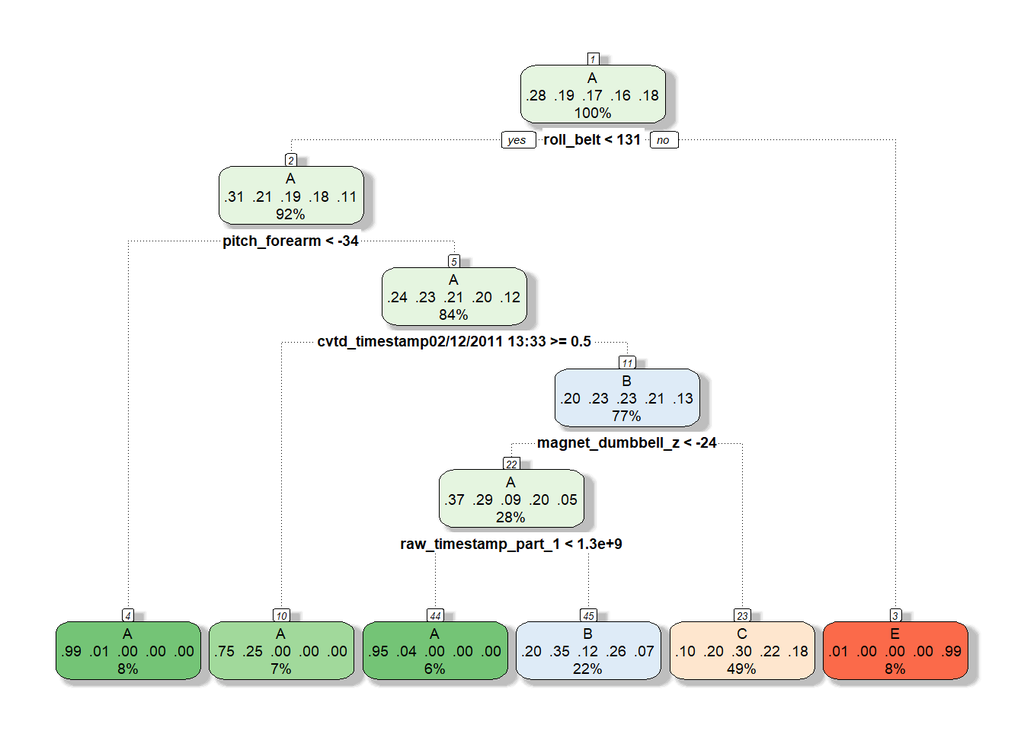

```r
suppressWarnings(fancyRpartPlot(fittree$finalModel, sub= " "))
```

```r
predtree <- predict(fittree, test)
testTREE <- test
testTREE$predicted <- predtree
testTREE
```

```
##    raw_timestamp_part_1 raw_timestamp_part_2   cvtd_timestamp new_window
## 1            1323095002               868349 05/12/2011 14:23         no
## 2            1322673067               778725 30/11/2011 17:11         no
## 3            1322673075               342967 30/11/2011 17:11         no
## 4            1322832789               560311 02/12/2011 13:33         no
## 5            1322489635               814776 28/11/2011 14:13         no
## 6            1322673149               510661 30/11/2011 17:12         no
## 7            1322673128               766645 30/11/2011 17:12         no
## 8            1322673076                54671 30/11/2011 17:11         no
## 9            1323084240               916313 05/12/2011 11:24         no
## 10           1322837822               384285 02/12/2011 14:57         no
## 11           1323084277                36553 05/12/2011 11:24         no
## 12           1322673101               442731 30/11/2011 17:11         no
## 13           1322489661               298656 28/11/2011 14:14         no
## 14           1322673043               178652 30/11/2011 17:10         no
```

[output cut: 258 more lines]

### - Random Forest

```r
library(caret)
library(parallel)
library(doParallel)
cluster <- makeCluster(detectCores()-1)
registerDoParallel(cluster)
fitcontrol= trainControl(method="cv", number=5, allowParallel = TRUE)
fitrf <- train(classe~., data= train, method= "rf", trControl= fitcontrol)

stopCluster(cluster)
```

```r
fitrf
```

```
## Random Forest
##
## 19622 samples
##    57 predictor
##     5 classes: 'A', 'B', 'C', 'D', 'E'
##
## No pre-processing
## Resampling: Cross-Validated (5 fold)
## Summary of sample sizes: 15698, 15698, 15698, 15697, 15697
## Resampling results across tuning parameters:
##
##   mtry  Accuracy   Kappa
##    2    0.9950055  0.9936821
##   38    0.9994394  0.9992909
##   75    0.9991336  0.9989042
##
## Accuracy was used to select the optimal model using the largest value.
## The final value used for the model was mtry = 38.
```

```r
predrf <- predict(fitrf, test)
testRF <- test
testRF$predicted <- predrf
testRF
```

```
##    raw_timestamp_part_1 raw_timestamp_part_2   cvtd_timestamp new_window
## 1            1323095002               868349 05/12/2011 14:23         no
## 2            1322673067               778725 30/11/2011 17:11         no
## 3            1322673075               342967 30/11/2011 17:11         no
## 4            1322832789               560311 02/12/2011 13:33         no
## 5            1322489635               814776 28/11/2011 14:13         no
## 6            1322673149               510661 30/11/2011 17:12         no
## 7            1322673128               766645 30/11/2011 17:12         no
## 8            1322673076                54671 30/11/2011 17:11         no
## 9            1323084240               916313 05/12/2011 11:24         no
## 10           1322837822               384285 02/12/2011 14:57         no
## 11           1323084277                36553 05/12/2011 11:24         no
## 12           1322673101               442731 30/11/2011 17:11         no
## 13           1322489661               298656 28/11/2011 14:14         no
## 14           1322673043               178652 30/11/2011 17:10         no
```

[output cut: 258 more lines]

## Summary

In this dataset, Random Forest performs better than Classification Tree, so the predicted values from random forest should be adopted while only these two algorithms are considered.